# Course Project Introduction

Tobias Pitz

2020-01-07

# Introduction

This is just a test document for privat use based on the information necessary to pass the course project 1 in reproducible research.

Dataset “activity.csv” includes the following columns:

1. steps: number of steps taken in a 5-minute interval
2. date: date in YYYY-MM-DD format
3. interval: identifier for the 5-minute interval in which measurement was taken

# Tasks

1. Write a report that answers several questions
2. complete the entire assignment in a single R markdown document that can be processed by knitr and be transformed into HTML

# Presettings

```r
setwd("C:/Users/Tobias/Documents/coursera/Reproducible Research/Course Project 1")

packages<- c("dplyr","zip", "openxlsx", "ggplot2","xlsx", "lubridate", "tidyr")

lapply(packages, require, character.only = TRUE)
```

[output not shown]

# Read and transform Data

Initial use of: >download.file(url = “https://d396qusza40orc.cloudfront.net/repdata%2Fdata%2Factivity.zip” ,destfile = “activity.csv”, )

```r
Rawdata<-read.csv2(file = "activity.csv",sep = "," ,header = TRUE)
DailyData<-Rawdata%>%group_by(date)%>%summarise(Sum_Steps = sum(steps), Count_walked_intervals = n_distinct(steps))
```

## What is mean total number of steps taken per day?

Histogram of number of steps taken per day

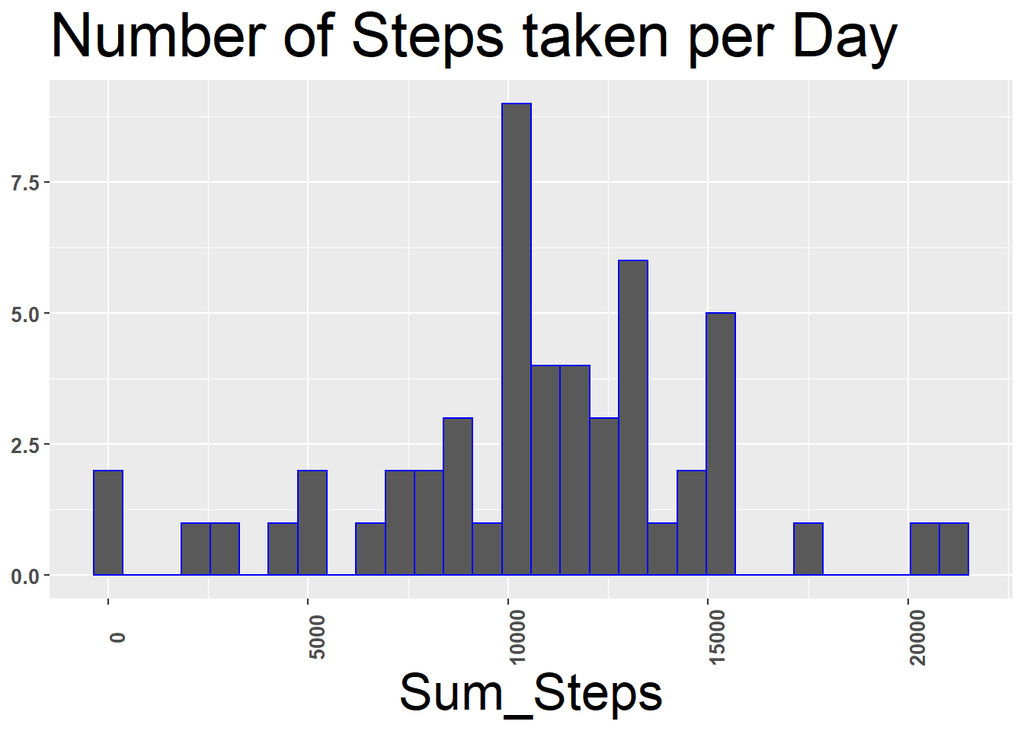

```r
ggplot(data = DailyData, aes(x= Sum_Steps))+
        geom_histogram(na.rm = TRUE,color = "blue")+
        theme(axis.title.y = element_blank()
              ,axis.text.x = element_text(angle=90, size=10, face="bold")
              ,axis.text.y = element_text(size= 10, face= "bold")
              ,title = element_text(size=25)
              ,legend.text = element_text(size= 15))+
        ggtitle("Number of Steps taken per Day")
```

Mean and media total number of steps taken per day

```r
Mean<-DailyData$Sum_Steps%>%mean(na.rm = TRUE)
Median<-DailyData$Sum_Steps%>%median(na.rm = TRUE)

Aggregates<-cbind(Mean, Median)
row.names(Aggregates)<-c("Steps_per_day")

print(Aggregates)
```

```
##                   Mean Median
## Steps_per_day 10766.19  10765
```

## Daily activity per 5-minute interval

Modify raw data

```r
Int_Steps<-Rawdata%>%group_by(interval)%>%summarise(mean_int_steps = mean(steps, na.rm = TRUE))%>%drop_na()
```

Time series graph

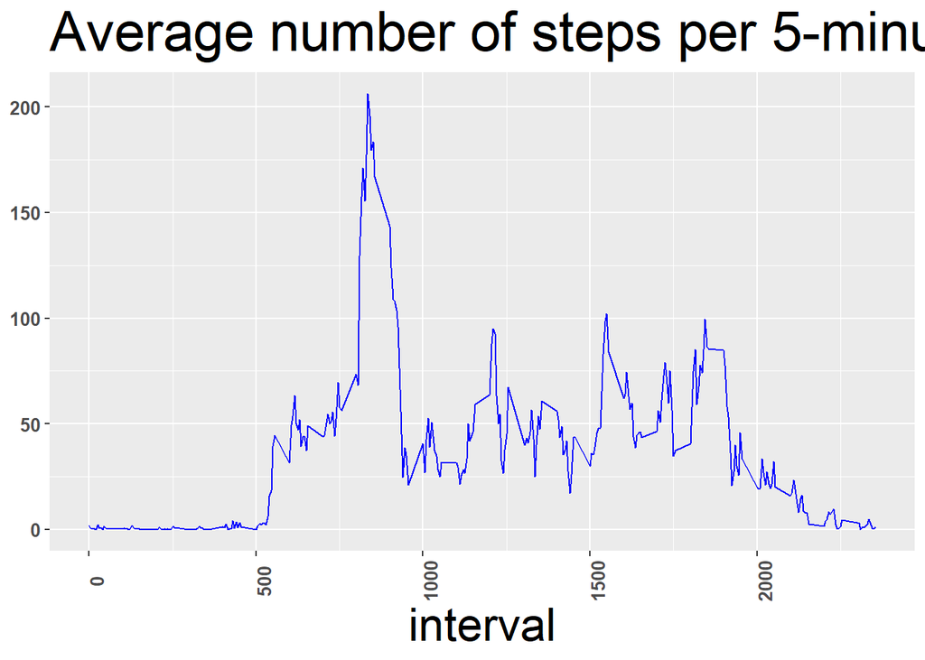

```r
ggplot(data = Int_Steps,aes(x = interval,y = mean_int_steps))+
                geom_line(na.rm = TRUE,stat = "identity", col = "blue", width = 1.5)+
        theme(axis.title.y = element_blank()
              ,axis.text.x = element_text(angle=90, size=10, face="bold")
              ,axis.text.y = element_text(size= 10, face= "bold")
              ,title = element_text(size=25)
              ,legend.text = element_text(size= 15))+
        ggtitle("Average number of steps per 5-minute interval")
```

Interval with max average number of steps

```r
Best_Int<-Int_Steps%>%filter(mean_int_steps == max(mean_int_steps))

print(Best_Int)
```

```
## # A tibble: 1 x 2
##   interval mean_int_steps
##      <int>          <dbl>
## 1      835           206.
```

Number of missing entries in steps column

```r
missing_steps<-Rawdata[which(is.na(Rawdata$steps)),]%>%nrow()

print(missing_steps)
```

```
## [1] 2304
```

Fill missing values with global mean per interval

```r
fill_mean<-mean(Int_Steps$mean_int_steps)%>%round(digits = 0)

print(fill_mean)
```

```
## [1] 37
```

Impute mean for NAs

```r
Imputed_Rawdata<- Rawdata%>%transform(steps = ifelse(is.na(Rawdata$steps), yes = fill_mean, no = Rawdata$steps))
```

Calculate new aggregates

```r
DailyData_2<-Imputed_Rawdata%>%group_by(date)%>%summarise(Sum_Steps = sum(steps))
```

Histogram:

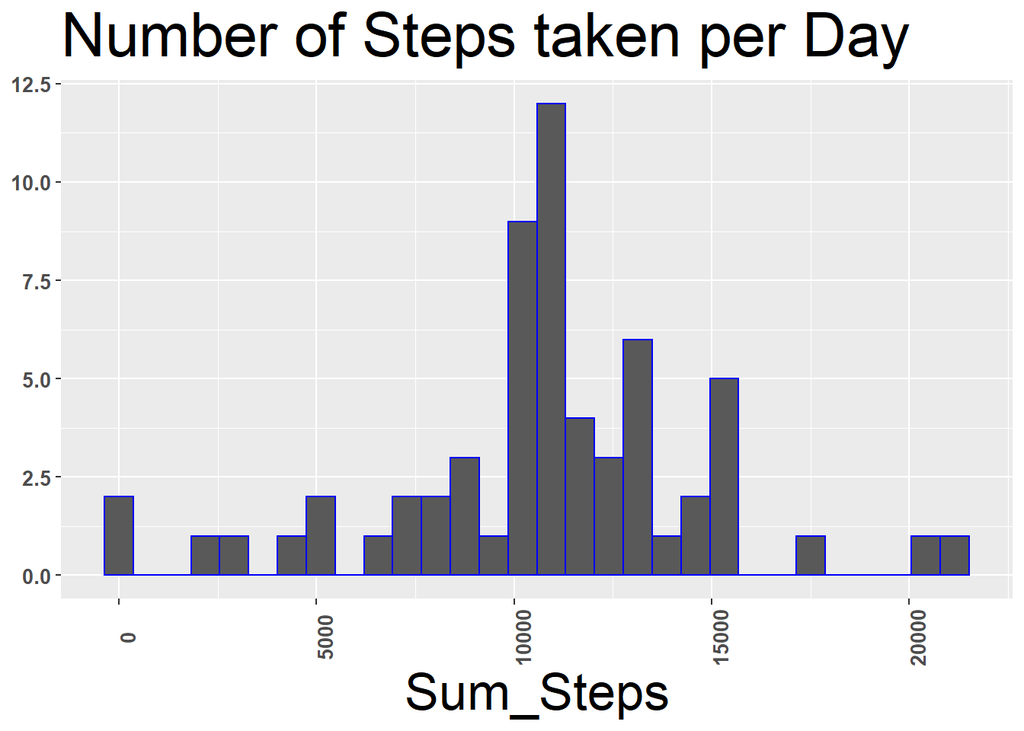

```r
ggplot(data = DailyData_2, aes(x= Sum_Steps))+
        geom_histogram(na.rm = TRUE,color = "blue")+
        theme(axis.title.y = element_blank()
              ,axis.text.x = element_text(angle=90, size=10, face="bold")
              ,axis.text.y = element_text(size= 10, face= "bold")
              ,title = element_text(size=25)
              ,legend.text = element_text(size= 15))+
        ggtitle("Number of Steps taken per Day")
```

```r
Mean_2<-DailyData_2$Sum_Steps%>%mean(na.rm = TRUE)
Median_2<-DailyData_2$Sum_Steps%>%median(na.rm = TRUE)

Aggregates_2<-cbind(Mean_2, Median_2)
row.names(Aggregates_2)<-c("Steps_per_day")
```

## Patterns at the Weekend vs. Workdays

Modify raw data / create day columns

```r
Data_Days<-Rawdata%>%mutate(date2 = as.POSIXct(date))%>%mutate(Weekday = weekdays(date2))%>%
        mutate(Weekend = ifelse(test = Weekday %in% c("Samstag", "Sonntag"),yes = 1,no = 0))
```

Create separate datasets

```r
Data_Weekend<-Data_Days%>%filter(Weekend == 1)
Data_Workday<-Data_Days%>%filter(Weekend == 0)
```

Aggregate data on interval level

```r
Int_Steps_Weekend<-Data_Weekend%>%group_by(interval)%>%summarise(mean_int_steps = mean(steps, na.rm = TRUE))%>%drop_na()

Int_Steps_Workday<-Data_Workday%>%group_by(interval)%>%summarise(mean_int_steps = mean(steps, na.rm = TRUE))%>%drop_na()
```

Plot time series

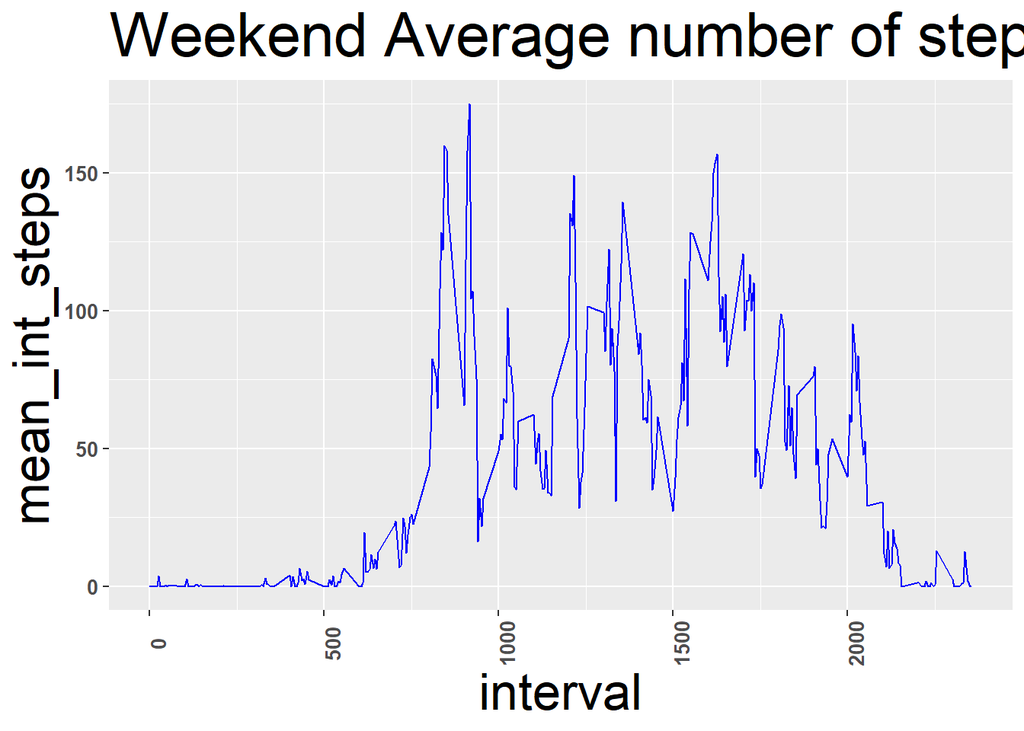

```r
ggplot(data = Int_Steps_Weekend,aes(x = interval,y = mean_int_steps))+
        geom_line(na.rm = TRUE,stat = "identity", col = "blue", width = 1.5)+
        theme(axis.text.x = element_text(angle=90, size=10, face="bold")
              ,axis.text.y = element_text(size= 10, face= "bold")
              ,title = element_text(size=25)
              ,legend.text = element_text(size= 15))+
        ggtitle("Weekend Average number of steps per 5-minute interval")
```

[figure not shown]

Workdays - movement behavior

```r
ggplot(data = Int_Steps_Workday,aes(x = interval,y = mean_int_steps))+
        geom_line(na.rm = TRUE,stat = "identity", col = "blue", width = 1.5)+
        theme(axis.text.x = element_text(angle=90, size=10, face="bold")
              ,axis.text.y = element_text(size= 10, face= "bold")
              ,title = element_text(size=25)
              ,legend.text = element_text(size= 15))+
        ggtitle("Workday Average number of steps per 5-minute interval")
```